# Connect1-Stigma: 4. Random forest

## Random forest models

**Method**

A random forest model consists of a group of individual classification trees. In a classification tree, all predictors are available to choose from at each split in the tree, and the model selects the predictor that best sorts cases into correct categories at that point. In a random forest model, only a randomly-selected subset of predictors is available to choose from for each tree in the forest, so every tree is constructed from a different set of predictors. Two parameters that can be adjusted are: the number of predictors per tree, and the number of splits per tree. At the end of the process, the predictions from all these trees are combined to give a final conclusion. A random forest model tends to be more accurate than a classification tree, because aggregating the predictions from multiple trees makes the model less sensitive to noise in the data. However, the results from a random forest model are less interpretable than the results from a simple tree.

The participants in this analysis were n=753 who have a four-frequency PTA of > 25 dB HL in their better ear and no missing data in 28 predictor variables and 1 outcome variable. Similar to a classification tree, I added case weights so that ‘Yes’ cases were more heavily weighted than ‘No’ cases. As before, a random forest model was built for 7 subsets of data to gauge model performance across different subsets of data. A final model was constructed with the full dataset.

**Results**

Each line in the plot is the average model accuracy across 7 subsets of data. In general, trees with more splits have higher accuracy, and changing the number of predictors doesn’t really affect accuracy. For trees with fewer splits, accuracy levels off at about 8 predictors per tree. The highest achieved accuracy is with 3 predictors per tree, and allowing the tree to grow to a maximum of 8 splits.

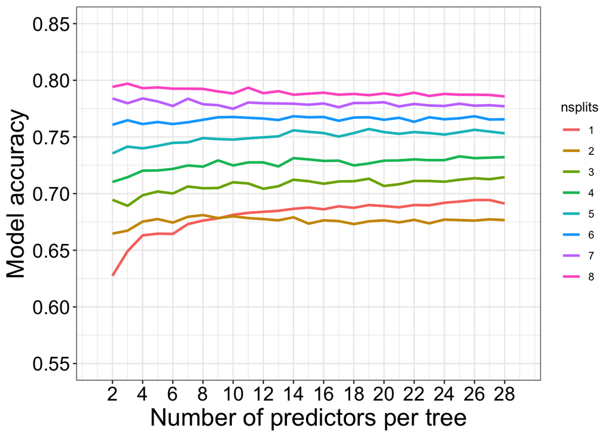

Using the full dataset and constructing a random forest model with 3 predictors per tree and a maximum tree depth of 8 splits, the model accuracy was 79%, but it had poor sensitivity (6%).

There were no parameters that led to a random forest model with good sensitivity and good specificity. Sensitivity never went above 52%. In the plot below, each point is a different model run on a subset of data, with varying numbers of predictors per tree and varying complexities of trees. Models that achieved the best compromise between sensitivity and specificity were very simple trees with few splits. The more complex the tree, the lower the sensitivity and higher the specificity.

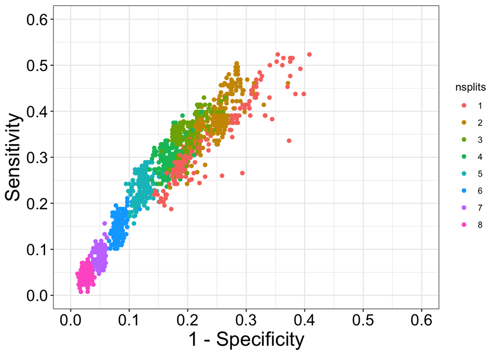

**Conclusion**

A simple classification tree (in the previous analysis) actually outperformed the random forest models in this analysis. Given that the results from a tree are more straightforward to interpret, I would choose to use a tree model over a random forest model.